# Regularized Logistic Regression

Shiny is a good way to demo your machine learning model or to submit your machine learning challenge so that others can quikly upload test data and get amazed by your nice model. In this notebook, we will build a regularized logistic regression that predicts whether microchips from a fabrication plant passes quality assurance (QA). During QA, each microchip goes through various tests to ensure it is functioning correctly. Suppose you are the product manager of the factory and you have the test results for some microchips on two diffeerent tests. From these two tests, you would like to determine whether the microchips should be accepted or rejected. Next, we will save the model and build a shiny app and test the app by uploading test data. Finally, we will download the data we uploaded with predictions using the machine learning model we buit below. The data is from the famous Machine Learning Coursera Course by Andrew Ng. The data can be downloaded from [here](http://datascience-enthusiast.com/data/ex2data2.txt).

**We will use the caret package for cross-validation and grid search**

```r
library(readr)
library(caret)
library(tidyverse)
```

## Read data, show sample

```r
df2 = read_csv("ex2data2.txt", col_names = FALSE)
head(df2)
```

| X1 | X2 | X3 |
| --- | --- | --- |
| 0.051267 | 0.69956 | 1 |
| -0.092742 | 0.68494 | 1 |
| -0.213710 | 0.69225 | 1 |
| -0.375000 | 0.50219 | 1 |
| -0.513250 | 0.46564 | 1 |
| -0.524770 | 0.20980 | 1 |

### Save 20 rows for testing

```r
reserved = df2 %>% sample_n(20)
df2_train = df2 %>% setdiff(reserved)
```

```r
dim(reserved)
```

```
[1] 20  3
```

```r
dim(df2_train)
```

```
[1] 98  3
```

```r
nrow(df2_train %>% intersect(reserved))
```

```
[1] 0
```

### Save the test data. We will upload this to the shiny app to get predictions

```r
write.csv(reserved, 'test_data.csv', row.names = FALSE)
```

### Name columns

```r
names(df2_train) = c("Test1", "Test2", "Label")
```

### Visualize the data

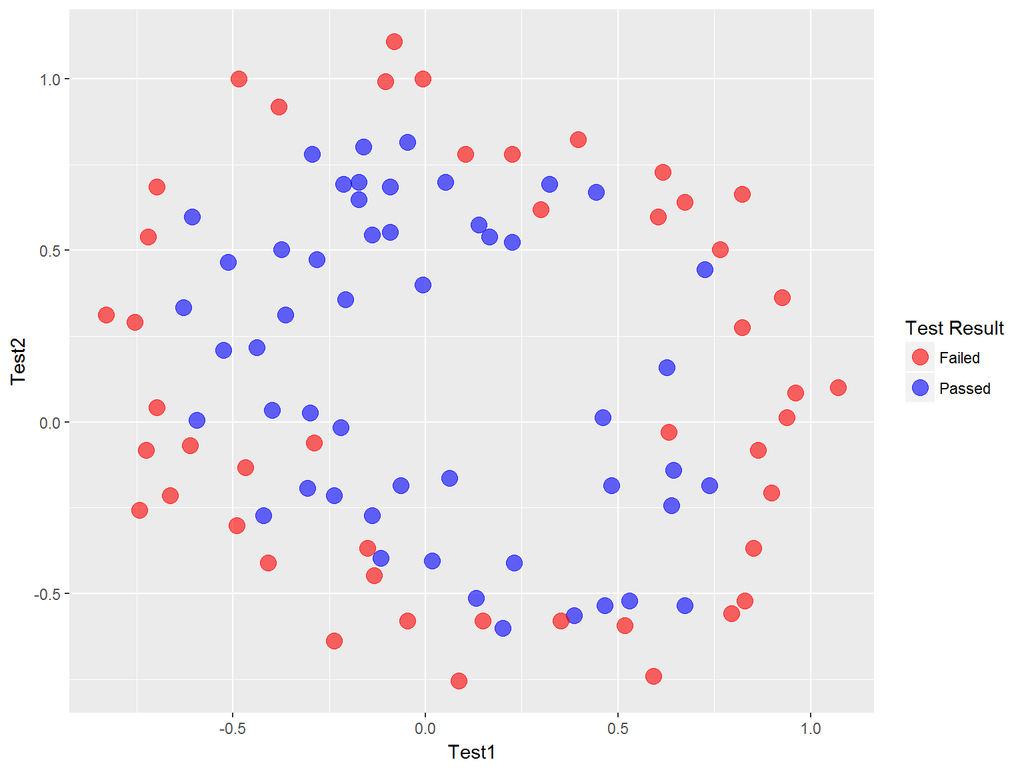

```r
cols <- c("0" = "red","1" = "blue")
df2_train %>% ggplot(aes(x = Test1, y = Test2, color = factor(Label))) + geom_point(size = 4, shape = 19, alpha = 0.6) +
scale_colour_manual(values = cols,labels = c("Failed", "Passed"),name="Test Result")
```

### Feature Engineering

The above figure shows that our dataset cannot be separated into positive and negative examples by a straight-line through the plot. Therefore, a straightforward application of logistic regression will not perform well on this dataset since logistic regression will only be able to find a linear decision boundary. One way to fit the data better is to create more features from each data point. Let’s map the features into all polynomial terms of x1 and x2 up to the sixth power. We have also to save this function for later use with the shiny app to create features from the uploaded data.

```r
feature_mapping = function(df){
       new_data = c()

    for(i in 1:6){
        for(j in 0:i){
            temp = (df$Test1)^i+(df$Test2)^(i-j)
            new_data = cbind(new_data,temp)
        }
    }

     colnames(new_data) = paste0("V",1:ncol(new_data))
    new_data
}
```

```r
mapped = feature_mapping(df2_train)
head(mapped)
```

```
            V1       V2        V3        V4       V5          V6
[1,]  0.750827 1.051267 0.4920125 0.7021883 1.002628  0.34248835
[2,]  0.592198 0.907258 0.4777439 0.6935411 1.008601  0.32053699
[3,]  0.478540 0.786290 0.5248820 0.7379220 1.045672  0.32197261
[4,]  0.127190 0.625000 0.3928198 0.6428150 1.140625  0.07391533
[5,] -0.047610 0.486750 0.4802462 0.7290656 1.263426 -0.03424282
[6,] -0.314970 0.475230 0.3193996 0.4851836 1.275384 -0.13527846
              V7         V8        V9        V10        V11       V12
[1,]  0.48951894 0.69969475 1.0001347 0.23950380 0.34236051 0.4893911
[2,]  0.46834512 0.68414232 0.9992023 0.22016895 0.32140865 0.4692168
[3,]  0.46944951 0.68248944 0.9902394 0.23172821 0.33381909 0.4812960
[4,]  0.19946042 0.44945563 0.9472656 0.08337761 0.14642510 0.2719702
[5,]  0.08161744 0.33043683 0.8647968 0.11640420 0.17035338 0.2862136
[6,] -0.10049699 0.06528697 0.8554870 0.07777351 0.08507067 0.1198521
           V13      V14         V15         V16         V17         V18
```

[output cut: 20 more lines]

```r
df_final = cbind(df2_train, mapped)
dim(df_final)
```

```
[1] 98 30
```

```r
df_final$Label = as.factor(df_final$Label )
```

```r
levels(df_final$Label) <- c("Failed", "Passed")
```

### Building a regularized logistic regression model using cross-validation and grid search

```r
set.seed(0)

cctrl1 <- trainControl(method = "cv", number = 10,
                       allowParallel = TRUE,
                       summaryFunction = twoClassSummary,
                       classProbs = TRUE
                       )


rlGrid <- expand.grid( cost = seq(0.001, 1, length.out = 20),
                       loss =  "L2_primal",
                       epsilon = 0.01 )

my_model <- train(Label ~ .,  data = df_final,
                  method = 'regLogistic',
                  trControl = cctrl1,
                  metric = "ROC",
                  preProc = c("center", "scale"),
                  tuneGrid = rlGrid)
my_model
```

```
Regularized Logistic Regression

98 samples
29 predictors
 2 classes: 'Failed', 'Passed'

Pre-processing: centered (29), scaled (29)
Resampling: Cross-Validated (10 fold)
Summary of sample sizes: 88, 88, 87, 88, 88, 89, ...
Resampling results across tuning parameters:

  cost        ROC        Sens   Spec
  0.00100000  0.7273333  0.575  0.8433333
  0.05357895  0.8356667  0.660  0.8200000
  0.10615789  0.8350000  0.705  0.8000000
  0.15873684  0.8303333  0.705  0.8200000
  0.21131579  0.8303333  0.685  0.8000000
  0.26389474  0.8303333  0.685  0.8000000
  0.31647368  0.8223333  0.685  0.8000000
  0.36905263  0.8173333  0.685  0.8000000
  0.42163158  0.8133333  0.685  0.8000000
  0.47421053  0.8133333  0.685  0.7800000
  0.52678947  0.8133333  0.685  0.7800000
  0.57936842  0.8133333  0.685  0.7800000
  0.63194737  0.8100000  0.685  0.7800000
  0.68452632  0.8060000  0.685  0.7800000
  0.73710526  0.8060000  0.685  0.7800000
  0.78968421  0.8060000  0.685  0.7600000
  0.84226316  0.8060000  0.685  0.7600000
  0.89484211  0.8060000  0.685  0.7600000
  0.94742105  0.8060000  0.685  0.7600000
  1.00000000  0.8060000  0.685  0.7600000

Tuning parameter 'loss' was held constant at a value of L2_primal

Tuning parameter 'epsilon' was held constant at a value of 0.01
ROC was used to select the optimal model using the largest value.
The final values used for the model were cost = 0.05357895, loss
 = L2_primal and epsilon = 0.01.
```

### Save the model. We will use it in the shiny app

```r
save(my_model , file = 'RegularizedLogisticRegression.rda')
```